# Analysis of American House Affordability

## Written by Brandon Daniel

Statement of Purpose  
Within the notebook, we will explore the US housing market to answer the following questions about the richest homeowners within our country.

1. Do certain regions see different age distributions than others?
2. Do certain areas of the country make significantly more than others (USD)?
3. Within these areas, how does the mean income change?
4. Do homeowners seem to be utilizing a larger percentage of their income on their home in certain regions?

> Utilized Modules  
> Understanding The Dataset  
> Tidying  
> Analysis

> > Age  
> > Income  
> > Burden

The Housing Affordability Data System (HADS) is a set of files derived from the 1985 and later national American Housing Survey (AHS) and the 2002 and later Metro AHS. This system categorizes housing units by affordability and households by income, with respect to the Adjusted Median Income, Fair Market Rent (FMR), and poverty income. It also includes housing cost burden for owner and renter households. These files have been the basis for the worst case needs tables since 2001. The data files are available for public use, since they were derived from AHS public use files and the published income limits and FMRs. We are providing these files give the community of housing analysts the opportunity to use a consistent set of affordability measures. For more information on this dataset as well as a direct link to it, click **[HERE](https://www.huduser.gov/portal/datasets/hads/hads.html)**

## Utilized Modules

Listed below are the modules required in order to perform this analysis. All documentation for using these modules can be found on their respective websites.

```python
import pandas
import numpy as np
import seaborn as sb
import matplotlib.pyplot as plt
import scipy
from IPython.display import display, HTML
from pandas.api.types import is_numeric_dtype
import re
from scipy.stats import levene
from scipy.stats import ttest_ind
from sklearn import linear_model
from scipy.stats import pearsonr
from scipy.stats import f_oneway
import warnings
import sys
from sklearn.model_selection import cross_val_score

warnings.filterwarnings(action='ignore') #hide runtime warning for loss of floating point precision
%matplotlib inline
```

## Understanding the Dataset

To begin, we will take a quick look at how the data was originally organized and give a brief rundown to what all of the features within our dataframe mean. We will also use this time to explore what datatypes are required for each feature and what certain acronyms within cells mean.

```python
housingRaw = pandas.read_csv('thads2013n.txt')
housingRaw.head()
```

|  | CONTROL | AGE1 | METRO3 | REGION | LMED | FMR | L30 | L50 | L80 | IPOV | ... | FMTINCRELFMRCAT | FMTCOST06RELAMICAT | FMTCOST08RELAMICAT | FMTCOST12RELAMICAT | FMTCOSTMEDRELAMICAT | FMTINCRELAMICAT | FMTASSISTED | FMTBURDEN | FMTREGION | FMTSTATUS |
| --- | --- | --- | --- | --- | --- | --- | --- | --- | --- | --- | --- | --- | --- | --- | --- | --- | --- | --- | --- | --- | --- |
| 0 | '100003130103' | 82 | '3' | '1' | 73738 | 956 | 15738 | 26213 | 40322 | 11067 | ... | '1 LTE 50% FMR' | '2 30 - 50% AMI' | '2 30 - 50% AMI' | '2 30 - 50% AMI' | '2 30 - 50% AMI' | '2 30 - 50% AMI' | '.' | '2 30% to 50%' | '-5' | '-5' |
| 1 | '100006110249' | 50 | '5' | '3' | 55846 | 1100 | 17165 | 28604 | 45744 | 24218 | ... | '3 GT FMR' | '4 60 - 80% AMI' | '4 60 - 80% AMI' | '6 100 - 120% AMI' | '4 60 - 80% AMI' | '7 120% AMI +' | '.' | '1 Less than 30%' | '-5' | '-5' |
| 2 | '100006370140' | 53 | '5' | '3' | 55846 | 1100 | 13750 | 22897 | 36614 | 15470 | ... | '2 50.1 - 100% FMR' | '4 60 - 80% AMI' | '5 80 - 100% AMI' | '6 100 - 120% AMI' | '4 60 - 80% AMI' | '4 60 - 80% AMI' | '.' | '3 50% or More' | '-5' | '-5' |
| 3 | '100006520140' | 67 | '5' | '3' | 55846 | 949 | 13750 | 22897 | 36614 | 13964 | ... | '2 50.1 - 100% FMR' | '6 100 - 120% AMI' | '7 120% AMI +' | '7 120% AMI +' | '5 80 - 100% AMI' | '4 60 - 80% AMI' | '.' | '1 Less than 30%' | '-5' | '-5' |
| 4 | '100007130148' | 26 | '1' | '3' | 60991 | 737 | 14801 | 24628 | 39421 | 15492 | ... | '3 GT FMR' | '3 50 - 60% AMI' | '3 50 - 60% AMI' | '3 50 - 60% AMI' | '3 50 - 60% AMI' | '7 120% AMI +' | '0 Not Assisted' | '1 Less than 30%' | '-5' | '-5' |

5 rows × 99 columns

As displayed above, the housing dataset that we are working with has 99 features for each row entry. Our sample output above does not display all of the feautures. Within our analysis, we will be focusing on several, but not all, of the features within this dataset. To begin, we will look at characteristics of each home with respect to the number of bedrooms, number of general rooms, number of occupants, the cost of utilities, market value of the house, and the year the house was built. We will then be looking at the financial status of the owner / occupants [Total household earnings] with respect to the following criteria. Area Median Income (AMI) and its four measures [Median Income(LMed), Low Income(L80), Very Low Income(L50), and Extremely Low Income(L30)], [Financial] Burden, affordability with respect to average rent, and other costs. Below we see the dataframe that we will be working. For a more thorough explaination to the meaning behind these characteristics, please consult the documentation for this dataset linked **[HERE](https://www.huduser.gov/portal/datasets/hads/HADS_doc.pdf)**

```python
housingFrame = pandas.DataFrame()
userFinancialFrame = pandas.DataFrame()

# grabbing the housing information
housingFrame['Owner\'s Age'] = housingRaw['AGE1' or 'age1']
housingFrame['Bedrooms'] = housingRaw['BEDRMS']
housingFrame['Year Built'] = housingRaw['BUILT']
housingFrame['Rooms'] = housingRaw['ROOMS']
housingFrame['Occupancy'] = housingRaw['PER']
housingFrame['Adequacy'] = housingRaw['FMTZADEQ']
housingFrame['Census Region'] = housingRaw['REGION']

# grabbing the financial information
housingFrame['L30'] = housingRaw['L30']
housingFrame['L50'] = housingRaw['L50']
housingFrame['L80'] = housingRaw['L80']
housingFrame['Area Median Income'] = housingRaw['LMED']
housingFrame['Household Income'] = housingRaw['ZINC2']
housingFrame['Household Wage Income'] = housingRaw['TOTSAL']
housingFrame['House Value'] = housingRaw['VALUE']
housingFrame['Monthly Housing Cost'] = housingRaw['COST08']
housingFrame['Burden'] = housingRaw['BURDEN']
housingFrame['Utilities'] = housingRaw['UTILITY']
housingFrame['Fair Market Line'] = housingRaw['FMR']

#custom CSS for output of dataframes
CSS = """
.output {
    flex-direction: row;
}
"""

HTML('<style>{}</style>'.format(CSS))

display(HTML('<h3><em>Housing DataFrame</em></h3>'))
display(housingFrame.head())
```

*Housing DataFrame*

|  | Owner's Age | Bedrooms | Year Built | Rooms | Occupancy | Adequacy | Census Region | L30 | L50 | L80 | Area Median Income | Household Income | Household Wage Income | House Value | Monthly Housing Cost | Burden | Utilities | Fair Market Line |
| --- | --- | --- | --- | --- | --- | --- | --- | --- | --- | --- | --- | --- | --- | --- | --- | --- | --- | --- |
| 0 | 82 | 2 | 2006 | 6 | 1 | '1 Adequate' | '1' | 15738 | 26213 | 40322 | 73738 | 18021 | 0 | 40000 | 696.905247 | 0.354919 | 169.000000 | 956 |
| 1 | 50 | 4 | 1980 | 6 | 4 | '1 Adequate' | '3' | 17165 | 28604 | 45744 | 55846 | 122961 | 123000 | 130000 | 1324.671218 | 0.047527 | 245.333333 | 1100 |
| 2 | 53 | 4 | 1985 | 7 | 2 | '1 Adequate' | '3' | 13750 | 22897 | 36614 | 55846 | 27974 | 28000 | 150000 | 1374.582175 | 0.602703 | 159.000000 | 1100 |
| 3 | 67 | 3 | 1985 | 6 | 2 | '1 Adequate' | '3' | 13750 | 22897 | 36614 | 55846 | 32220 | 0 | 200000 | 1820.442900 | 0.103911 | 179.000000 | 949 |
| 4 | 26 | 2 | 1980 | 4 | 2 | '1 Adequate' | '3' | 14801 | 24628 | 39421 | 60991 | 96874 | 96900 | -6 | 759.000000 | 0.094019 | 146.000000 | 737 |

## Tidying

After extracting the features that we will be using for future analysis, we can begin formatting the data into a manner that is consistent and easy to work with. We will also begin checking the data to see if any cells were not populated with an appropriate value during initial recording. The first points to address and the values for the **Adequacy** and **Census Region** features.

```python
housingFrame['Adequacy'].unique()
```

```
array(["'1 Adequate'", "'2 Moderately Inadequ'", "'-5'",
       "'3 Severely Indadequa'"], dtype=object)
```

We see above that the general format of adequacy seems to be an integer following by the descriptor string with the exception of the '-5' being used. This '-5' corresponds to the housing being vacant, therefore, a thorough survey of the home could not be conducted. In order to clean this information, we will convert these to strings.

```python
def rawToFormattedAdequacy(adequateSeries):
    """
    Given the raw form of the the adequacy series in the dataframe,
    converts it into a clean series where all values are strictly
    human-readable descriptions.

    rType: Numpy Array
    """
    adequacyRegex = r".*\d (\w+)( \w+)*.*"
    descriptors = list()

    for cell in adequateSeries:
        matchResult = re.match(adequacyRegex, cell, re.I)

        if matchResult:
            if matchResult.group(2) != None:
                descriptors.append(str(matchResult.group(1)) + " Inadequate")
            else:
                descriptors.append(str(matchResult.group(1)))
        else:
            descriptors.append("Vacant")

    return np.asarray(descriptors)

#test functionality
rawToFormattedAdequacy(housingFrame['Adequacy'].sample(10))
```

```
array(['Adequate', 'Adequate', 'Adequate', 'Adequate', 'Adequate',
       'Adequate', 'Adequate', 'Adequate', 'Adequate', 'Adequate'],
      dtype='<U8')
```

Now that we have a function to convert the raw data into something more user-friendly, we can move to the conversion of the data within the Census Region column into something more descriptive. More specifically, we will replace the number corresponding to the census region with the name of the region. Region names are provided by the [Census Bureau](https://www2.census.gov/geo/docs/maps-data/maps/reg_div.txt)

```python
housingFrame['Census Region'].unique()
```

```
array(["'1'", "'3'", "'4'", "'2'"], dtype=object)
```

Once again, we check to see what regions are represented. All regions are represented within our dataset. We can now begin converting the IDs for each region into their respective title.

```python
def rawToFormattedCensus(censusSeries):
    """
    Given the series corresponding to the raw census region data,
    return the official title of the region
    """
    censusTitles = list()

    for cell in censusSeries:
        if cell == "'1'":
            censusTitles.append("North-East")
        elif cell == "'2'":
            censusTitles.append("Mid-West")
        elif cell == "'3'":
            censusTitles.append("South")
        else:
            censusTitles.append("West")

    return np.asarray(censusTitles)


rawToFormattedCensus(housingFrame['Census Region'].sample(10))
```

```
array(['Mid-West', 'North-East', 'South', 'South', 'West', 'North-East',
       'West', 'Mid-West', 'West', 'Mid-West'],
      dtype='<U10')
```

With the function to convert these values into more descriptive entries done, we can apply the two functions to our dataframe. We can then focus on finding any outliers in the integer-based data within the other columns. Anything that could go unnoticed such as negative values where negatives should not be permitted or determining if specific values were entered that have a special meaning with respect to the documentation.

```python
# apply clarity functions to dataframe
housingFrame['Census Region'] = rawToFormattedCensus(housingFrame['Census Region'])
housingFrame['Adequacy'] = rawToFormattedAdequacy(housingFrame['Adequacy'])
housingFrame.head(5)
```

|  | Owner's Age | Bedrooms | Year Built | Rooms | Occupancy | Adequacy | Census Region | L30 | L50 | L80 | Area Median Income | Household Income | Household Wage Income | House Value | Monthly Housing Cost | Burden | Utilities | Fair Market Line |
| --- | --- | --- | --- | --- | --- | --- | --- | --- | --- | --- | --- | --- | --- | --- | --- | --- | --- | --- |
| 0 | 82 | 2 | 2006 | 6 | 1 | Adequate | North-East | 15738 | 26213 | 40322 | 73738 | 18021 | 0 | 40000 | 696.905247 | 0.354919 | 169.000000 | 956 |
| 1 | 50 | 4 | 1980 | 6 | 4 | Adequate | South | 17165 | 28604 | 45744 | 55846 | 122961 | 123000 | 130000 | 1324.671218 | 0.047527 | 245.333333 | 1100 |
| 2 | 53 | 4 | 1985 | 7 | 2 | Adequate | South | 13750 | 22897 | 36614 | 55846 | 27974 | 28000 | 150000 | 1374.582175 | 0.602703 | 159.000000 | 1100 |
| 3 | 67 | 3 | 1985 | 6 | 2 | Adequate | South | 13750 | 22897 | 36614 | 55846 | 32220 | 0 | 200000 | 1820.442900 | 0.103911 | 179.000000 | 949 |
| 4 | 26 | 2 | 1980 | 4 | 2 | Adequate | South | 14801 | 24628 | 39421 | 60991 | 96874 | 96900 | -6 | 759.000000 | 0.094019 | 146.000000 | 737 |

Above we have our dataframe with the new values for *Census Region* and *Adequacy* placed appropriately. We now will look at all of the integer-populated columns to ensure values are well formed (non-negative).

```python
columnsToTest = list(housingFrame.columns)
columnsToTest = list(filter(lambda x: x not in ["Adequacy", "Census Region"] , columnsToTest))

housingFrame[housingFrame[columnsToTest[0]] < 0].head(5)
```

|  | Owner's Age | Bedrooms | Year Built | Rooms | Occupancy | Adequacy | Census Region | L30 | L50 | L80 | Area Median Income | Household Income | Household Wage Income | House Value | Monthly Housing Cost | Burden | Utilities | Fair Market Line |
| --- | --- | --- | --- | --- | --- | --- | --- | --- | --- | --- | --- | --- | --- | --- | --- | --- | --- | --- |
| 27 | -9 | 2 | 1980 | 5 | -6 | Vacant | South | 12190 | 20301 | 32462 | 56613 | -6 | -9 | -6 | 731.000000 | -9.0 | 0.000000 | 868 |
| 74 | -9 | 0 | 1990 | 1 | -6 | Vacant | South | 16434 | 27384 | 40379 | 77954 | -6 | -9 | -6 | 1845.000000 | -9.0 | 0.000000 | 749 |
| 77 | -9 | 1 | 2005 | 3 | -6 | Vacant | South | 12837 | 21389 | 34008 | 59547 | -6 | -9 | -6 | 515.000000 | -9.0 | 0.000000 | 589 |
| 104 | -9 | 2 | 1980 | 4 | -6 | Vacant | South | 12150 | 20200 | 32350 | 57700 | -6 | -9 | -6 | 186.666667 | -9.0 | 143.000000 | 776 |
| 115 | -9 | 4 | 2004 | 7 | -6 | Vacant | West | 20550 | 34300 | 54850 | 86300 | -6 | -9 | 490000 | 3990.068438 | -9.0 | 33.333333 | 3100 |

Interestingly enough, these negative vales show up in multiple columns. As further elaborated upon in the documentation, these neagtive values correspond to missing fields. The sample above tells us that the Owner's age, Income, Occupany, and House Value could not be determined as a result of the home being *Vacant* as appropriately labeled in the **Adequacy** column. To get a better sense of how much of our data corresponds to vacancy, we will get some basic summary statistics and then determine whether or not we should replace these numbers with something more consisitent

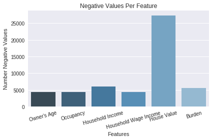

```python
vacantValues = dict()

for feature in columnsToTest:
    negatives = sum(1 for value in housingFrame[feature] if value < 0)
    if negatives > 0:
        vacantValues[feature] = negatives

#plot negative values found
ax = sb.barplot(x=list(vacantValues.keys()), y=list(vacantValues.values()),palette="Blues_d")
ax.set_xticklabels(ax.get_xticklabels(), rotation=15)
ax.set_title("Negative Values Per Feature")
ax.set_ylabel("Number Negative Values")
ax.set_xlabel("Features")
plt.tight_layout()
```

```python
sampleSize = housingFrame.size
vacantHomes = sum(1 for entry in housingFrame['Adequacy'] if entry == 'Vacant')
noValueHomes = sum(1 for entry in housingFrame['House Value'] if entry < 0)
vacancyProportion = vacantHomes / sampleSize;
noHouseValProportion = noValueHomes / sampleSize;

print("Using a sample size of {}, we see the following statistics.".format(sampleSize))
print("% {0:.2f} of the homes within the sample are vacant".format(vacancyProportion * 100))
print("% {0:.2f} of the homes within the sample were given no value".format(noHouseValProportion * 100))
```

```
Using a sample size of 1161630, we see the following statistics.
% 0.38 of the homes within the sample are vacant
% 2.36 of the homes within the sample were given no value
```

Based on the ratios with respect to the sample size, simply dropping all of the homes with no given value could impose too large of an effect on our sample variance. On the other hand, we can drop the values associated with vacant homes since we will prefer to look at living conditions of homeowners / families in their current home.

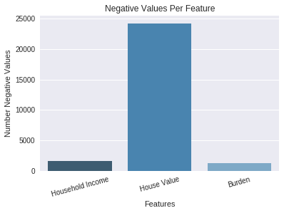

```python
housingFrame = housingFrame[housingFrame['Adequacy'] != 'Vacant']
vacantValues = dict()

for feature in columnsToTest:
    negatives = sum(1 for value in housingFrame[feature] if value < 0)
    if negatives > 0:
        vacantValues[feature] = negatives

# plot all negative values found
ax = sb.barplot(x=list(vacantValues.keys()), y=list(vacantValues.values()),palette="Blues_d")
ax.set_xticklabels(ax.get_xticklabels(), rotation=15)
ax.set_title("Negative Values Per Feature")
ax.set_ylabel("Number Negative Values")
ax.set_xlabel("Features")
```

After dropping the entries marked as *Vacant* from the dataframe, we see large change in the number of ill-formed values. Both the the number of negative values for *Household Income* and *Burder* have dropped significantly and the negative values from the *Owner's Age, Occupancy, and Household Wage Income* have been completely eliminated. Based on the documentation, the negative values associated with *Burden* and *Household Income* correspond to homeowners not needing to pay by third party means whether it be, "Household receiving a subsidy", "Unit is public housing","Household has a voucher", "Applied to management to get public housing." To keep our data as descriptive as possible, we will replace the negative values associated with each feature with a new value based on an appropriate machine learning model. We will predict the House value based on the Income associated with the house, the monthly housing cost, and the burden. To make computations easier, we will create a new feature called *Max Income* in order to avoid instances where a retired individual's wage income would be zero but houshold income would be non zero. Only considering one of these options could drastically throw off our model.

```python
# create the new series with the highest available income
generalIncome = housingFrame['Household Income']
wageIncome = housingFrame['Household Wage Income']
incomes = pandas.concat([generalIncome, wageIncome], axis=1).max(axis=1)
housingFrame['Max Income'] = incomes
housingFrame.head()
```

|  | Owner's Age | Bedrooms | Year Built | Rooms | Occupancy | Adequacy | Census Region | L30 | L50 | L80 | Area Median Income | Household Income | Household Wage Income | House Value | Monthly Housing Cost | Burden | Utilities | Fair Market Line | Max Income |
| --- | --- | --- | --- | --- | --- | --- | --- | --- | --- | --- | --- | --- | --- | --- | --- | --- | --- | --- | --- |
| 0 | 82 | 2 | 2006 | 6 | 1 | Adequate | North-East | 15738 | 26213 | 40322 | 73738 | 18021 | 0 | 40000 | 696.905247 | 0.354919 | 169.000000 | 956 | 18021 |
| 1 | 50 | 4 | 1980 | 6 | 4 | Adequate | South | 17165 | 28604 | 45744 | 55846 | 122961 | 123000 | 130000 | 1324.671218 | 0.047527 | 245.333333 | 1100 | 123000 |
| 2 | 53 | 4 | 1985 | 7 | 2 | Adequate | South | 13750 | 22897 | 36614 | 55846 | 27974 | 28000 | 150000 | 1374.582175 | 0.602703 | 159.000000 | 1100 | 28000 |
| 3 | 67 | 3 | 1985 | 6 | 2 | Adequate | South | 13750 | 22897 | 36614 | 55846 | 32220 | 0 | 200000 | 1820.442900 | 0.103911 | 179.000000 | 949 | 32220 |
| 4 | 26 | 2 | 1980 | 4 | 2 | Adequate | South | 14801 | 24628 | 39421 | 60991 | 96874 | 96900 | -6 | 759.000000 | 0.094019 | 146.000000 | 737 | 96900 |

Above you can see our new feature in our housing dataframe that simply takes the max of the household income and the household wage income. Now that this step has been completed, we can focus on finding a good model for imputation. Let's take a look at this data to see if we can extract any hints to what model we should use. To begin, we will extract some possibly helpful features from our dataframe (*Max Income* and *Monthly Housing Cost* )

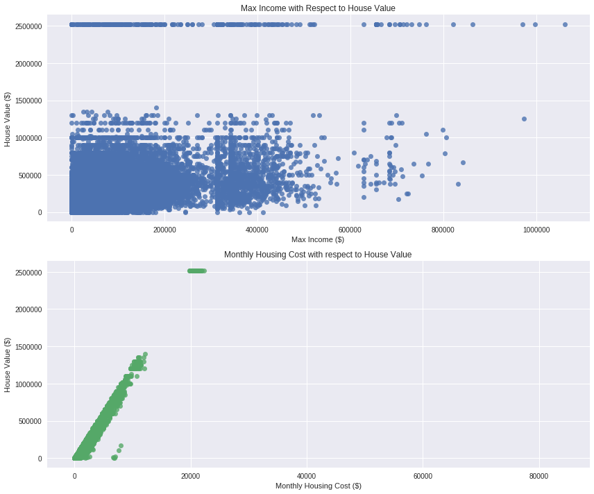

```python
#obtain training and testing data for our model
housingData = housingFrame[housingFrame['House Value'] > 0]
housingData = housingData[['Max Income', 'Monthly Housing Cost', 'House Value']]

#visualize housing value based on three input features
f, (ax1, ax2) = plt.subplots(nrows=2)
f.set_figheight(10)
f.set_figwidth(12)

sb.regplot(x='Max Income',y='House Value', data=housingData, ax=ax1, fit_reg=False)
ax1.set_title('Max Income with Respect to House Value')
ax1.set_xlabel('Max Income ($)')
ax1.set_ylabel('House Value ($)')

sb.regplot(x='Monthly Housing Cost', y='House Value', data=housingData, ax=ax2, fit_reg=False)
ax2.set_title('Monthly Housing Cost with respect to House Value')
ax2.set_xlabel('Monthly Housing Cost ($)')
ax2.set_ylabel('House Value ($)')
plt.tight_layout()
```

Looking at the two plots above, the data within the first plot (Max Income with respect to House value) seems to be arbitrarily scattered under \$400,000 with no clear pattern. The second plot on the other hand (Monthly Housing Cost with respect to House Value) seems to be showing a linear pattern. Since we are able to observe a linear pattern in the scatter plot, we can proceed by training a linear model where the *Monthly Housing Cost* predicts our *House Value* to most accurately represent the relationship we want to recreate.

```python
# prepare data for training
trainingSet = housingData.sample(frac=.9)       # extract simple random sample of 90% of dataframe for training
X = np.asarray(trainingSet['Monthly Housing Cost'])
X = X.reshape(len(X), 1)
y = np.asarray(trainingSet['House Value'])
y = y.reshape(len(y), 1)
testingSet = housingData                        # use remaining 10% for testing
XTest = np.asarray(testingSet['Monthly Housing Cost'])
XTest = XTest.reshape(len(XTest), 1)
yTest = np.asarray(testingSet['House Value'])
yTest = yTest.reshape(len(yTest), 1)

#k fold cv testing the model
houseValModel = linear_model.LinearRegression(fit_intercept=False)
print("Cross validation scores")
print(cross_val_score(houseValModel, X, y, cv=10))
print()

houseValModel.fit(X,y)
print("Testing Set Score: {0:0.5f} accurate".format(houseValModel.score(XTest, yTest)))
```

```
Cross validation scores
[ 0.98427717  0.98800863  0.98586768  0.98329438  0.98675204  0.9871856
  0.98471683  0.98827802  0.98366993  0.98413954]

Testing Set Score: 0.98576 accurate
```

```python
# fill in negative house values with estimates
inputedValues = np.zeros(len(housingFrame['House Value']))
counter = 0

for indx, row in housingFrame.iterrows():
    houseValue = row['House Value']
    if houseValue < 0:
        inputedValues[counter] = houseValModel.predict(row['Monthly Housing Cost']).flatten()[0]
    else:
        inputedValues[counter] = houseValue
    counter += 1

housingFrame['House Value'] = inputedValues

# show how many missing fields are left
negatives = sum(1 for value in housingFrame['Monthly Housing Cost'] if value < 0)
print("There are {} missing house values".format(negatives))
```

```
There are 0 missing house values
```

```python
housingFrame.sample(5)
```

|  | Owner's Age | Bedrooms | Year Built | Rooms | Occupancy | Adequacy | Census Region | L30 | L50 | L80 | Area Median Income | Household Income | Household Wage Income | House Value | Monthly Housing Cost | Burden | Utilities | Fair Market Line | Max Income |
| --- | --- | --- | --- | --- | --- | --- | --- | --- | --- | --- | --- | --- | --- | --- | --- | --- | --- | --- | --- |
| 12878 | 55 | 3 | 1960 | 6 | 2 | Adequate | South | 15700 | 26200 | 41850 | 49000 | 112974 | 113000 | 201653.931829 | 1756.000000 | 0.186521 | 253.000000 | 1539 | 113000 |
| 46718 | 68 | 3 | 1950 | 7 | 3 | Adequate | West | 22400 | 37300 | 59650 | 61900 | 94400 | 48000 | 1.000000 | 276.007854 | 0.040424 | 209.333333 | 1921 | 94400 |
| 43180 | 44 | 3 | 2006 | 6 | 1 | Adequate | South | 13025 | 21697 | 34702 | 60060 | 75987 | 76000 | 140000.000000 | 1461.210030 | 0.414860 | 292.166667 | 1282 | 76000 |
| 4703 | 61 | 2 | 1940 | 6 | 2 | Adequate | North-East | 17331 | 28935 | 46126 | 71452 | 162300 | 155000 | 180000.000000 | 1661.031943 | 0.042957 | 189.000000 | 936 | 162300 |
| 62166 | 34 | 3 | 1980 | 5 | 4 | Adequate | South | 17165 | 28604 | 45744 | 55846 | 17000 | 13000 | 36288.520762 | 316.000000 | 0.223059 | 195.000000 | 949 | 17000 |

Displayed above we see that all of the missing home values have been imputed using our model. We also see a small sample of our dataset which has been cleaned and is ready for analysis.

## Exploratory Analysis

To break up the data into more manageable pieces for our analysis, we will begin by splitting up the entries by **Census Region**. This will also allow us to understand how the housing market changes based off of the different census regions.

### Analysis of Age

To begin, let's take a look at the age to household income distribution throughout the four Census regions.

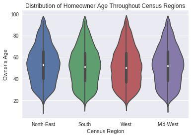

```python
ax = sb.violinplot(x="Census Region", y="Owner's Age", data=housingFrame)
ax.set_title("Distribution of Homeowner Age Throughout Census Regions")
```

Above we see violin plots tothe distribution of homeowner's age with respect to the four Census Regions. All four plots have similar shapes with the exception of some curvature differences below the age of 40. 50-60 year olds seem to be the primary owners of homes throughout all of our figures. But, the Western census region has the least noticable peak in the distribution between the 50-60 age range. To get clearer sense of the differences at the lower age bracket, we can focus in its violin plot.

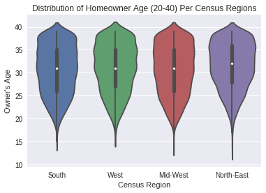

```python
lowerAgeBracket = housingFrame[housingFrame['Owner\'s Age'] < 40]
ax = sb.violinplot(x="Census Region", y="Owner's Age", data=lowerAgeBracket)
ax.set_title("Distribution of Homeowner Age (20-40) Per Census Regions")
```

Taking a closer look at the distributions in the youngest age range we see that the south, west, and mid-west seem to be quite similar in our sample. The North-East seems to have a higher 25% and 75% percentile as well as a higher mean than the others. This leads us to wonder whether or not there is a reason why homeowners within the lower age grouping are older in the North East census region.

### Analysis of Income

To begin, we will take a look at the different incomes that we see throughout the regions and see whether there is a significant difference in incomes. To handle the instances where an individual is retired and not recieving an income, we will use the max of the wage income and the general income.

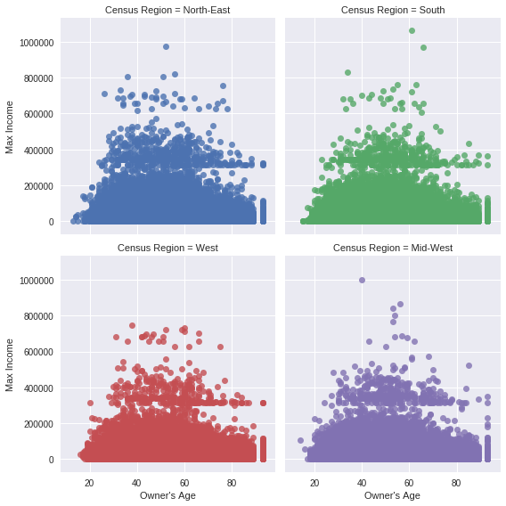

```python
# visualization of income with respect to age for each region
ax = sb.lmplot(x="Owner's Age", y="Max Income", col="Census Region", hue="Census Region",
                data=housingFrame, col_wrap=2, size=4, fit_reg=False)
```

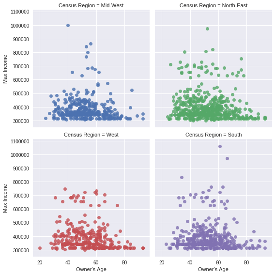

```python
# extract the 300k+ income owners from frame
richestOwners = housingFrame[housingFrame['Max Income'] > 300000]
sb.lmplot(x="Owner's Age", y="Max Income", col="Census Region", hue="Census Region",
                data=richestOwners, col_wrap=2, size=4, fit_reg=False)
```

$$H_0 : \sigma^2_0 = \sigma^2_1 = \sigma^2_2 = \sigma^2_3$$ $$H_a : \text{at least one is not equal where}$$

$$ \sigma^2_0 \text{ is the true variance for the southern region's maximum income}$$ $$\sigma^2_1 \text{ is the true variance for the north-eastern region's maximum income}$$ $$\sigma^2_2 \text{ is the true variance for the western region's maximum income}$$ $$\sigma^2_3 \text{ is the true variance for the midwestern region's maximum income}$$

```python
southSample = richestOwners[richestOwners['Census Region'] == 'South']['Max Income']
northSample = richestOwners[richestOwners['Census Region'] == 'North-East']['Max Income']
westSample = richestOwners[richestOwners['Census Region'] == 'West']['Max Income']
midwestSample = richestOwners[richestOwners['Census Region'] == 'Mid-West']['Max Income']
southSample.name = 'South'
northSample.name = 'North-East'
westSample.name = 'West'
midwestSample.name = 'Mid-West'

W,p = levene(southSample, northSample, westSample, midwestSample)
print("We see a p-value of {0:0.5f}".format(p))
```

```
We see a p-value of 0.08212
```

Since we have obtained a p-value of greater than $\alpha = .01$, (or even greater than $\alpha = .05$) we do not have sufficient evidence to say that the true variances of the samples differ. With this information in mind, we can now perform a Welch's t test in order to see if there exists a statistically significant difference between the true means of our sample without assuming equal variances. We formally define this hypothesis below.

$$H_0 : \mu_0 = \mu_1 = \mu_2 = \mu_3$$ $$H_a : \text{at least one is not equal where}$$

$$ \mu_0 \text{ is the true mean for the southern region sample}$$ $$\mu_1 \text{ is the true mean for the north-eastern region sample}$$ $$\mu_2 \text{ is the true mean for the western region sample}$$ $$\mu_3 \text{ is the true mean for the midwestern region sample}$$

```python
samples = [southSample, northSample, westSample, midwestSample]
p_values = list()
alpha = .01

#perform the test on each region's sample
while(len(samples) > 0):
    sample1 = samples.pop()
    for sample2 in samples:
        _, p = ttest_ind(sample1, sample2, equal_var=False)
        p_values.append((sample1.name, sample2.name, p))

# log the samples that showed statistically significant difference in true mean
for (sampleName1, sampleName2, result) in p_values:
    if result < alpha:
        print("There is a statistically significant difference between {0} and {1} with p-value of {2:0.5f}"
              .format(sampleName1, sampleName2, result))
```

The results of the Welch's test over all of the samples tell us that there is not a statistically significant difference between the true means of the samples with a significance level of $\alpha = .01$. To get a better grasp into how the mean incomes for the regions differ, let's look at some basic summary statistics.

```python
# take basic sample statistics for each region
midwestMean = midwestSample.mean()
midwestSTD = midwestSample.std()
northMean = northSample.mean()
northSTD = northSample.std()
westMean = westSample.mean()
westSTD = westSample.std()
southMean = southSample.mean()
southSTD = southSample.std()

#aggregate for simple visualization
sampleStats = pandas.DataFrame()
sampleStats['Region'] = ['Mid-West', 'North-East', 'West', 'South']
sampleStats['Mean'] = [midwestMean, northMean, westMean, southMean]
sampleStats['Standard Deviation'] = [midwestSTD, northSTD, westSTD, southSTD]
sampleStats.round(3)
```

|  | Region | Mean | Standard Deviation |
| --- | --- | --- | --- |
| 0 | Mid-West | 382521.061 | 84210.594 |
| 1 | North-East | 396220.754 | 97617.579 |
| 2 | West | 392103.759 | 95810.532 |
| 3 | South | 388761.010 | 99908.159 |

Our sample statistics calculated above show us why there was not a significant difference between the regions. While we do see quite a large difference between the highest mean income area [North-East] and the lowest [Mid-West], the standard deviations for these areas are too large to give us concrete evidence. Now that we have looked at the average income of the richest grouping of homeowners, lets shift our focus to how much they are spending on their homes and utilities.

### Analysis of Financial Burden

We will begin by taking a look to how much money homeowners with a salary > $300k have been putting into their homes. With respect to the dataset's variables, we will be focusing on *Burden*

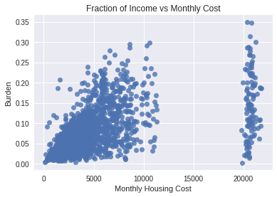

```python
ax = sb.regplot(x="Monthly Housing Cost", y="Burden", data=richestOwners, fit_reg=False)
ax.set_title("Fraction of Income vs Monthly Cost")
```

In the plot above, we see how the monthly cost of the home affects the homeowner's monthly imcome. It's quite interesting how there is such a clear divide between those who spend under \$ 10,000 on their home versus those to spend over \$ 20,000. Regardless, we see that a majority of homeowners in our richest bracket [300k+] seem to be pretty good at keeping their monthly expenses below %25 of their income. We can also observe a positive linear scatter between the 0 to 15,000 marks. Let's see how this changes when we break up the data into respective census regions.

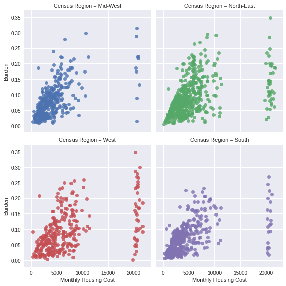

```python
sb.lmplot(x="Monthly Housing Cost", y="Burden", col="Census Region", hue="Census Region",
                data=richestOwners, col_wrap=2, size=4, fit_reg=False)
```

Above we see the new burder vs monthly housing cost plots for each of the four census regions. It is surprising that all four regions seem to be showing the same distribution under ten thousand with the burden varying at the twenty thousand dollar mark as well. One difference I do notice from this plot is that there seems to be a more dense cluster of homeowners with monthly housing cost at 20 thousand in the West and North-East regions. To get a better undering to how burden is (or is not) differing between the regions, let's perform a test for difference between the true means of the burden. As we did before, we must first check to see whether, or not, we can assume that the true variances of the distribution are equal with a levene's test. We formally define our test by

$$H_0 : \sigma^2_0 = \sigma^2_1 = \sigma^2_2 = \sigma^2_3$$ $$H_a : \text{at least one is not equal where}$$

$$ \sigma^2_0 \text{ is the true variance for the southern region's percent burden}$$ $$\sigma^2_1 \text{ is the true variance for the north-eastern region's percent burden}$$ $$\sigma^2_2 \text{ is the true variance for the western region's percent burden}$$ $$\sigma^2_3 \text{ is the true variance for the midwestern region's percent burden}$$

```python
southSample = richestOwners[richestOwners['Census Region'] == 'South']['Burden']
northSample = richestOwners[richestOwners['Census Region'] == 'North-East']['Burden']
westSample = richestOwners[richestOwners['Census Region'] == 'West']['Burden']
midwestSample = richestOwners[richestOwners['Census Region'] == 'Mid-West']['Burden']
southSample.name = 'South'
northSample.name = 'North-East'
westSample.name = 'West'
midwestSample.name = 'Mid-West'

W,p = levene(southSample, northSample, westSample, midwestSample)
print("We see a p-value of {0:0.5f}".format(p))
```

```
We see a p-value of 0.00026
```

$$H_0 : \mu_0 = \mu_1 = \mu_2 = \mu_3$$ $$H_a : \text{at least one is not equal where}$$

$$ \mu_0 \text{ is the true mean for the southern region's percent burden}$$ $$\mu_1 \text{ is the true mean for the north-eastern region's percent burden}$$ $$\mu_2 \text{ is the true mean for the western region's percent burden}$$ $$\mu_3 \text{ is the true mean for the midwestern region's percent burden}$$

```python
_, p = f_oneway(southSample, northSample, westSample, midwestSample)
print("P value: {0:0.4f}".format(p))
```

```
P value: 0.0000
```

Written by Brandon Daniel